# Introduction to RNAseq

Research Informatics Core

June 16, 2026

# 1 Morning

## 1.1 Download reference transcriptome GTF file

### 1.1.1 Let’s make a new folder to do today’s exercises in

```bash
mkdir ~/rnaseq
cd ~/rnaseq
```

### 1.1.2 Download from Ensembl FTP site using wget

- How to find the URL if you don’t want to type it in:
  - Google: “Ensembl ftp”, should be the first link
  - Direct link: http://useast.ensembl.org/info/data/ftp/index.html/
  - Click on the link for “Mouse” and “Gene sets (GTF)”
  - Right-click on the line “Mus_musculus.GRCm39.115.gtf.gz” and copy to clipboard
  - In the terminal: type “wget”, paste in the link. **Note, the download will go faster if you change “http” to “ftp”**:

```bash
## NOTE: ENSEMBL updates these annotations regularly, so the
## link may be slightly different, and the contents slightly different
## from what we report below
wget ftp://ftp.ensembl.org/pub/release-115/gtf/mus_musculus/Mus_musculus.GRCm39.115.gtf.gz
```

- Downloaded file: Mus_musculus.GRCm39.115.gtf.gz

Note: you can find links to the whole genome fasta file and GTF file for mouse from the same Ensembl site, if you were to run the gene-level quantification approach.

### 1.1.3 Take a peek at the file

- gzip -d (decompress) -c (print to stdout)

```bash
gzip -dc Mus_musculus.GRCm39.115.gtf.gz | head
```

```
#!genome-build GRCm39
#!genome-version GRCm39
#!genome-date 2020-06
#!genome-build-accession GCA_000001635.9
#!genebuild-last-updated 2025-05
1       havana  gene    108344807       108347562       .       +       .       gene_id "ENSMUSG00000104478"; gene_version "2"; gene_name "Gm38212"; gene_source "havana"; gene_biotype "TEC";
1       havana  transcript      108344807       108347562       .       +       .       gene_id "ENSMUSG00000104478"; gene_version "2"; transcript_id "ENSMUST00000194081"; transcript_version "2"; gene_name "Gm38212"; gene_source "havana"; gene_biotype "TEC"; transcript_name "Gm38212-201"; transcript…
1       havana  exon    108344807       108347562       .       +       .       gene_id "ENSMUSG00000104478"; gene_version "2"; transcript_id "ENSMUST00000194081"; transcript_version "2"; exon_number "1"; gene_name "Gm38212"; gene_source "havana"; gene_biotype "TEC"; transcript_name "Gm38212-201"; t…
1       havana  gene    6980784 6981446 .       +       .       gene_id "ENSMUSG00000104385"; gene_version "2"; gene_name "Gm7449"; gene_source "havana"; gene_biotype "processed_pseudogene";
1       havana  transcript      6980784 6981446 .       +       .       gene_id "ENSMUSG00000104385"; gene_version "2"; transcript_id "ENSMUST00000194393"; transcript_version "2"; gene_name "Gm7449"; gene_source "havana"; gene_biotype "processed_pseudogene"; transcript_name "Gm7449-201"; transcript_…
```

### 1.1.4 Get summary statistics of the GTF file

- Count the number of exons

```
gzip -dc Mus_musculus.GRCm39.115.gtf.gz | cut -f3 | grep -wc exon
1298756
```

- Count the number of distinct gene IDs

```
gzip -dc Mus_musculus.GRCm39.115.gtf.gz | grep "gene_id" |
 sed 's/.*gene_id "//;s/".*//' | sort | uniq | wc -l
78298
```

## 1.2 Run STAR alignment and gene expression quantification

### 1.2.1 Copy the run_STAR_alignment.sh script to the current folder

```bash
cd ~/rnaseq
cp  /workshops/ric_workshop/common/4_RNAseq/run_STAR_alignment.sh .
```

### 1.2.2 We will use a pre-built STAR index directory, due to the length of time it takes to build the index, and our example fastq files.

```bash
ln -s /workshops/ric_workshop/common/4_RNAseq/mm39_STAR

ln -s /workshops/ric_workshop/common/4_RNAseq/raw_data/control_S4_L001_R1_001.fastq.gz
ln -s /workshops/ric_workshop/common/4_RNAseq/raw_data/control_S4_L001_R2_001.fastq.gz
```

### 1.2.3 Take a look at the script

```bash
nano run_STAR_alignment.sh
```

- The script should look like this:

```bash
#!/bin/sh
#SBATCH --mail-type=BEGIN,END,FAIL
#SBATCH --time=10:00:00
#SBATCH --mem=100G
#SBATCH --ntasks=4
#SBATCH --account=ric_workshop
#SBATCH --partition=batch
#SBATCH -o %x.o%J

cd $SLURM_SUBMIT_DIR
module load STAR

gzip -d Mus_musculus.GRCm39.115.gtf.gz

STAR --genomeDir mm39_STAR --runThreadN 8 --sjdbGTFfile Mus_musculus.GRCm39.115.gtf
 --readFilesCommand zcat
 --readFilesIn control_S4_L001_R1_001.fastq.gz control_S4_L001_R2_001.fastq.gz
 --outFileNamePrefix Control_S4_STAR
 --outSAMtype BAM Unsorted --quantMode GeneCounts

 gzip Mus_musculus.GRCm39.115.gtf
```

- Exit using Ctrl+X

### 1.2.4 Submit the script. We will return to the lecture while the script is running.

- This will take about 17 minutes to run

```bash
sbatch run_STAR_alignment.sh
```

### 1.2.5 Check what the outputs look like

- Reads are divided by strandedness
- Column 1 is gene ID
- Column 2 is counts for unstranded RNA-seq
- Column 3 is counts for the first strand (forward)
- Column 4 is counts for the second strand (reverse)

```bash
head Control_S4_STARReadsPerGene.out.tab

N_unmapped  3892526 3892526 3892526
N_multimapping  3984464 3984464 3984464
N_noFeature 13160465    14729833    30188940
N_ambiguous 1581786 495578  48574
ENSMUSG00000104478  0   0   0
ENSMUSG00000104385  0   0   0
ENSMUSG00000101231  0   0   0
ENSMUSG00000102135  0   0   0
ENSMUSG00000103282  0   0   0
ENSMUSG00000101097  0   0   0
```

### 1.2.6 Infer strandedness from the output using R

**ALL REMAINING STEPS FOR THIS EXERCISE ARE ON YOUR COMPUTER!**

- Make a directory called ‘workshop’ on your desktop.
- Open R Studio and change the working directory to ‘workshop’

[figure not shown]

- Now set ‘workshop’ folder as your working directory

[figure not shown]

- Download the counts file to your computer with WinSCP (Windows) or CyberDuck (Mac)

Use the SFTP client of your choice to download the Control_S4_STARReadsPerGene.out.tab file to your computer. Make sure it is in the workshop directory.

```r
data <- read.table("Control_S4_STARReadsPerGene.out.tab", row.names=1, sep="\t")

colnames(data) <- c("Unstranded", "Forward", "Reverse")

# Subset to only rows with gene expression counts
data_subset <- data[grepl("^ENSMUSG", rownames(data)), ]

# Calculate the sum of counts for each column
col_sums <- colSums(data_subset[, c("Unstranded", "Forward", "Reverse")])

#Infer strandedness
forward <- col_sums["Forward"]

reverse <- col_sums["Reverse"]

#Unstranded if the difference between forward and reverse is very small.
#Otherwise, forward or reverse stranded depending on which column sum is greater.
if (abs(forward - reverse) / max(forward, reverse) < 0.1) {
  strandedness <- "Unstranded"
} else if (forward > reverse) {
  strandedness <- "Stranded (reads match gene strand)"
} else {
  strandedness <- "Stranded (reads are antisense to gene)"
}

cat("Inferred strandedness:", strandedness)
```

```
Inferred strandedness: Stranded (reads match gene strand)
```

## 1.3 Build Kallisto index

### 1.3.1 Copy the index.sh script to the current folder and create a link to the FASTA file

```bash
cd ~/rnaseq
cp  /workshops/ric_workshop/common/4_RNAseq/index.sh .
ln -s /workshops/ric_workshop/common/4_RNAseq/Mus_musculus.GRCm39.cdna.all.fa.gz
```

### 1.3.2 Take a look at the script

```bash
nano index.sh
```

- The script should look like this:

```bash
#!/bin/sh
#SBATCH --mail-type=BEGIN,END,FAIL
#SBATCH --time=10:00:00
#SBATCH --mem=100G
#SBATCH --ntasks=4
#SBATCH --account=ric_workshop
#SBATCH --partition=batch
#SBATCH -o %x.o%J

cd $SLURM_SUBMIT_DIR

module load kallisto
kallisto index -i mm39.idx Mus_musculus.GRCm39.cdna.all.fa.gz
```

- Exit using Ctrl+X

### 1.3.3 Then submit the script

- This will take about 5 minutes to run

```bash
sbatch index.sh
```

Note: if the script fails for some reason, you can copy our pre-built index ln -s /workshops/ric_workshop/common/4_RNAseq/mm39.idx

## 1.4 Run Kallisto alignment

### 1.4.1 Will use our example fastq files

```bash
ln -s /workshops/ric_workshop/common/raw_data/4_RNAseq/control_S4_L001_R1_001.fastq.gz
ln -s /workshops/ric_workshop/common/raw_data/4_RNAseq/control_S4_L001_R2_001.fastq.gz
```

### 1.4.2 Copy the run_kallisto_alignment.sh script to the current folder

```bash
cd ~/rnaseq
cp  /workshops/ric_workshop/common/4_RNAseq/run_kallisto_alignment.sh .
```

### 1.4.3 Take a look at the script

```bash
nano run_kallisto_alignment.sh
```

- The script should look like this:

```bash
#!/bin/sh
#SBATCH --mail-type=BEGIN,END,FAIL
#SBATCH --time=10:00:00
#SBATCH --mem=100G
#SBATCH --ntasks=4
#SBATCH --account=ric_workshop
#SBATCH --partition=batch
#SBATCH -o %x.o%J

cd $SLURM_SUBMIT_DIR
module load kallisto
kallisto quant -i mm39.idx -o Control_S4_kallisto control_S4_L001_R1_001.fastq.gz
control_S4_L001_R2_001.fastq.gz
```

- Exit using Ctrl+X

### 1.4.4 Submit the script

```bash
sbatch run_kallisto_alignment.sh
```

- This will take around 9 minutes to run

### 1.4.5 Check what the outputs look like

- Transcript IDs in first column
- Estimated counts in fourth column
- Note that we don’t have the sample name in the fourth column. We should add that when we write the pipeline.

```bash
head Control_S4_kallisto/abundance.tsv

target_id   length  eff_length  est_counts  tpm
ENSMUST00000103301.3    359 182.461 0   0
ENSMUST00000166255.2    278 117.058 0   0
ENSMUST00000095364.3    294 129.317 0   0
ENSMUST00000103304.3    374 195.451 1   0.486559
ENSMUST00000103305.2    362 185.246 0   0
ENSMUST00000103306.2    362 185.246 0   0
ENSMUST00000200586.2    359 182.461 0   0
ENSMUST00000103309.3    341 167.147 0   0
ENSMUST00000103310.3    358 181.693 0   0
```

# 2 Afternoon

## 2.1 EdgeR analysis

### 2.1.1 Run differential analysis in edgeR using R Studio

- Start a new R script and save it to your computer as “edgeR.R”
- Execute the edgeR commands one-at-a-time. See comments below about what each step is doing.
- NOTE: check the path to the gene_result.txt file you downloaded to use in the read.table() command
- edgeR website (https://bioconductor.org/packages/release/bioc/html/edgeR.html)
- edgeR manual (https://bioconductor.org/packages/release/bioc/manuals/edgeR/man/edgeR.pdf)

```r
library(edgeR)
# read in counts from our public website
data <- read.table("https://wd.cri.uic.edu/RNAseq/gene_result.txt",header=T,row.names=1)
```

```r
dim(data)
```

```
[1] 51714     6
```

```r
# subset counts to transcripts with >20 total counts
# want to remove transcripts with too little data to test
data_subset <- data[rowSums(data)>20,]
dim(data_subset)
```

```
[1] 21031     6
```

```r
# define sample groups
metadata <- c("C","C","C","D","D","D")
# create edgeR object
genes <- DGEList(counts=data_subset, group=metadata)
genes
```

```
An object of class "DGEList"
$counts
                   control_S4 control_S5 control_S6 disease_S1 disease_S2
ENSMUSG00000100764          7          7          3         16          9
ENSMUSG00000100480         10          3         14         11         16
ENSMUSG00000100025          3          8          3          6          6
ENSMUSG00000051285       4914       2602       3553       4618       4080
ENSMUSG00000103509       1144        625        934       1095        724
                   disease_S3
ENSMUSG00000100764         13
ENSMUSG00000100480         10
ENSMUSG00000100025          5
ENSMUSG00000051285       4830
ENSMUSG00000103509       1057
21026 more rows ...

$samples
           group lib.size norm.factors
control_S4     C 17432496            1
control_S5     C 10885848            1
control_S6     C 15243297            1
disease_S1     D 21111134            1
disease_S2     D 17717438            1
disease_S3     D 24070038            1
```

```r
# calculate TMM factors
genes <- calcNormFactors(genes)
genes
```

```
An object of class "DGEList"
$counts
                   control_S4 control_S5 control_S6 disease_S1 disease_S2
ENSMUSG00000100764          7          7          3         16          9
ENSMUSG00000100480         10          3         14         11         16
ENSMUSG00000100025          3          8          3          6          6
ENSMUSG00000051285       4914       2602       3553       4618       4080
ENSMUSG00000103509       1144        625        934       1095        724
                   disease_S3
ENSMUSG00000100764         13
ENSMUSG00000100480         10
ENSMUSG00000100025          5
ENSMUSG00000051285       4830
ENSMUSG00000103509       1057
21026 more rows ...

$samples
           group lib.size norm.factors
control_S4     C 17432496    1.0110849
control_S5     C 10885848    0.9991490
control_S6     C 15243297    1.0159544
disease_S1     D 21111134    0.9966066
disease_S2     D 17717438    0.9890745
disease_S3     D 24070038    0.9884510
```

```r
# estimate dispersion
genes <- estimateDisp(genes)
```

```
Using classic mode.
```

```r
genes
```

```
An object of class "DGEList"
$counts
                   control_S4 control_S5 control_S6 disease_S1 disease_S2
ENSMUSG00000100764          7          7          3         16          9
ENSMUSG00000100480         10          3         14         11         16
ENSMUSG00000100025          3          8          3          6          6
ENSMUSG00000051285       4914       2602       3553       4618       4080
ENSMUSG00000103509       1144        625        934       1095        724
                   disease_S3
ENSMUSG00000100764         13
ENSMUSG00000100480         10
ENSMUSG00000100025          5
ENSMUSG00000051285       4830
ENSMUSG00000103509       1057
21026 more rows ...

$samples
           group lib.size norm.factors
control_S4     C 17432496    1.0110849
control_S5     C 10885848    0.9991490
control_S6     C 15243297    1.0159544
disease_S1     D 21111134    0.9966066
disease_S2     D 17717438    0.9890745
disease_S3     D 24070038    0.9884510

$common.dispersion
[1] 0.03565371

$trended.dispersion
[1] 0.13151352 0.12136434 0.14007789 0.02199388 0.02075094
21026 more elements ...

$tagwise.dispersion
[1] 0.07387103 0.11820153 0.15732584 0.01461695 0.01418889
21026 more elements ...

$AveLogCPM
[1] -0.6739281 -0.4802125 -1.2892478  7.8697139  5.7413367
21026 more elements ...

$trend.method
[1] "locfit"

$prior.df
[1] 4.042901

$prior.n
[1] 1.010725

$span
[1] 0.2865693
```

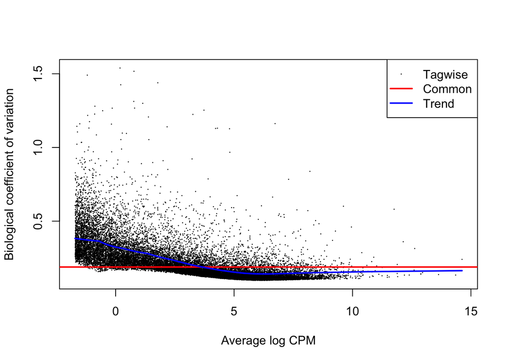

```r
plotBCV(genes)
```

```r
# run differential
stats <- exactTest(genes)
# NOTE: logFC will be computed as D/C: positive means higher in D
#       edgeR calculates this as the second group over the first
#       group from exactTest
stats
```

```
An object of class "DGEExact"
$table
                         logFC     logCPM      PValue
ENSMUSG00000100764  0.62239589 -0.6739281 0.285015316
ENSMUSG00000100480  0.01998717 -0.4802125 1.000000000
ENSMUSG00000100025 -0.28574084 -1.2892478 0.697748717
ENSMUSG00000051285 -0.19017485  7.8697139 0.186675965
ENSMUSG00000103509 -0.40734225  5.7413367 0.005326131
21026 more rows ...

$comparison
[1] "C" "D"

$genes
NULL
```

```r
# run FDR correction
QValue <- p.adjust(stats$table$PValue,method="BH")
# add to the test$table data frame
stats$table <- cbind(stats$table,QValue)
diff <- stats$table
head(diff)
```

|  | logFC | logCPM | PValue | QValue |
| --- | --- | --- | --- | --- |
| ENSMUSG00000100764 | 0.62239589 | -0.6739281 | 0.285015316 | 0.52686623 |
| ENSMUSG00000100480 | 0.01998717 | -0.4802125 | 1.000000000 | 1.00000000 |
| ENSMUSG00000100025 | -0.28574084 | -1.2892478 | 0.697748717 | 0.86562270 |
| ENSMUSG00000051285 | -0.19017485 | 7.8697139 | 0.186675965 | 0.40662685 |
| ENSMUSG00000103509 | -0.40734225 | 5.7413367 | 0.005326131 | 0.03123644 |
| ENSMUSG00000097797 | 0.95989012 | 0.1967624 | 0.033694905 | 0.12710987 |

```r
# calculate normalized expression
norm <- cpm(genes)
head(norm)
```

```
                    control_S4  control_S5  control_S6  disease_S1  disease_S2
ENSMUSG00000100764   0.3971466   0.6435844   0.1937172   0.7604745   0.5135853
ENSMUSG00000100480   0.5673523   0.2758219   0.9040135   0.5228262   0.9130405
ENSMUSG00000100025   0.1702057   0.7355251   0.1937172   0.2851779   0.3423902
ENSMUSG00000051285 278.7969044 239.2295244 229.4257102 219.4919586 232.8253258
ENSMUSG00000103509  64.9050994  57.4628950  60.3106145  52.0449750  41.3150823
ENSMUSG00000097797   0.4538818   1.1032876   0.5811515   1.3308304   1.4836908
                    disease_S3
ENSMUSG00000100764   0.5464009
ENSMUSG00000100480   0.4203084
ENSMUSG00000100025   0.2101542
ENSMUSG00000051285 203.0089666
ENSMUSG00000103509  44.4265999
ENSMUSG00000097797   1.1768636
```

```r
# write tables to files - col.names=NA adds an extra tab to the first row
write.table(diff,"diff.txt",sep="\t",quote=F,col.names=NA)
write.table(norm,"norm.txt",sep="\t",quote=F,col.names=NA)
```

Save this R script

## 2.2 Gene filtering in R

### 2.2.1 Filtering on DE stats

```r
# sort genes by significance: we can order on PValue because sometimes there are ties
# in the QValue. But, ordered by PValue will also be ordered by QValue.
diff.sorted <- diff[order(diff$PValue),]
head(diff.sorted)
```

|  | logFC | logCPM | PValue | QValue |
| --- | --- | --- | --- | --- |
| ENSMUSG00000020186 | 3.164954 | 6.690888 | 2.249931e-93 | 4.731830e-89 |
| ENSMUSG00000020218 | 7.356998 | 3.365530 | 2.882694e-79 | 3.031297e-75 |
| ENSMUSG00000044708 | 4.118091 | 4.878290 | 8.968429e-78 | 6.287168e-74 |
| ENSMUSG00000042631 | 3.269708 | 4.452494 | 4.257873e-61 | 2.238683e-57 |
| ENSMUSG00000024598 | 3.321944 | 5.674823 | 9.881824e-60 | 4.156493e-56 |
| ENSMUSG00000039385 | 3.366400 | 4.308574 | 1.063543e-55 | 3.727897e-52 |

```r
# filter genes by significance
degs.diff <- diff[diff$QValue < 0.05,]
dim(degs.diff)
```

```
[1] 4146    4
```

```r
# filter genes by significance AND fold-change
degs.diff2 <- diff[diff$QValue < 0.05 & abs(diff$logFC) > 1,]
dim(degs.diff2)
```

```
[1] 2074    4
```

### 2.2.2 Mapping to gene symbols

- Will use the rtracklayer package with the GTF file downloaded previously to extract gene symbols and annotate EdgeR results

Use the SFTP client (WinSCP for Windows or CyberDuck for Mac) to download the Mus_musculus.GRCm39.115.gtf.gz file to your computer.

```r
# Load the rtracklayer library
library(rtracklayer)
# Specify the path to your gzipped GTF file
gtf_file <- "Mus_musculus.GRCm39.115.gtf.gz"

# Import the GTF file into R (handles gzipped files automatically)
gtf_data <- import(gtf_file, format = "gtf")

# Filter the data to include only gene features
genes <- gtf_data[gtf_data$type == "gene", ]

# Extract gene IDs and gene symbols into a data frame
gene_info <- data.frame(
  gene_id = genes$gene_id,
  gene_symbol = genes$gene_name
)

head(gene_info)
```

|  | gene_id | gene_symbol |
| --- | --- | --- |
| 1 | ENSMUSG00000104478 | Gm38212 |
| 2 | ENSMUSG00000104385 | Gm7449 |
| 3 | ENSMUSG00000101231 | Gm28283 |
| 4 | ENSMUSG00000101097 | Gm6679 |
| 5 | ENSMUSG00000100764 | Gm29155 |
| 6 | ENSMUSG00000100831 | Gm17847 |

```r
# Annotate the differential analysis results with the gene symbols (may read from saved file or URL)
# Will be used later for volcano plots

diff <- read.table("diff.txt", row.names=1, header=T, sep="\t")

diff <- read.table("https://wd.cri.uic.edu/RNAseq/diff.txt", row.names=1, header=T, sep="\t")

matching_indices <- match(rownames(diff), gene_info$gene_id)
diff$gene_symbol <- gene_info$gene_symbol[matching_indices]
head(diff)
```

|  | logFC | logCPM | PValue | QValue | gene_symbol |
| --- | --- | --- | --- | --- | --- |
| ENSMUSG00000100764 | 0.62239588 | -0.6739281 | 0.28501534 | 0.52686627 | Gm29155 |
| ENSMUSG00000100480 | 0.01998718 | -0.4802125 | 1.00000000 | 1.00000000 | Gm29156 |
| ENSMUSG00000100025 | -0.28574085 | -1.2892478 | 0.69774874 | 0.86562269 | Gm8141 |
| ENSMUSG00000051285 | -0.19017485 | 7.8697139 | 0.18667596 | 0.40662685 | Pcmtd1 |
| ENSMUSG00000103509 | -0.40734225 | 5.7413367 | 0.00532613 | 0.03123643 | Gm38372 |
| ENSMUSG00000097797 | 0.95989012 | 0.1967624 | 0.03369492 | 0.12710993 | Gm26901 |

```r
write.table(diff, "diff_annotated.txt",sep="\t",quote=F,col.names=NA)
```

## 2.3 PCA plot

- Use the normalized expression data.

```r
# Read in the normalized data table from our public URL


norm <- read.table("https://wd.cri.uic.edu/RNAseq/norm.txt",header=T,row.names=1)

# log-scale the data first (this is good practice, as gene expression varies
#    over several orders of magnitude)
# add a pseudo-count (0.1) to avoid taking the log of 0
norm.log <- log2(norm + 0.1)
# run PCA on the transpose of cpm.log: we want to plot the SAMPLES
# Here we don't need to use SCALE=T, because it's normalized expression so the
#    average expression per SAMPLE should be the same
pca <- prcomp(t(norm.log))

# Create a data frame from PCA results
pca_df <- data.frame(
  PC1 = pca$x[, 1],
  PC2 = pca$x[, 2],
  Name = colnames(norm)
  )

pca_df
```

|  | PC1 | PC2 | Name |
| --- | --- | --- | --- |
| control_S4 | -52.26958 | 58.27495733 | control_S4 |
| control_S5 | -61.15414 | -20.44709039 | control_S5 |
| control_S6 | -50.99743 | -31.51943566 | control_S6 |
| disease_S1 | 51.53646 | -0.09744389 | disease_S1 |
| disease_S2 | 70.90295 | 15.69585178 | disease_S2 |
| disease_S3 | 41.98174 | -21.90683916 | disease_S3 |

```r
#Add sample information from the metadata file

metadata <- read.table("https://wd.cri.uic.edu/RNAseq/metadata.txt",header=T)
metadata
```

| Name | Condition |
| --- | --- |
| control_S4 | Control |
| control_S5 | Control |
| control_S6 | Control |
| disease_S1 | Disease |
| disease_S2 | Disease |
| disease_S3 | Disease |

```r
pca_df <- merge(pca_df, metadata, by = "Name")
pca_df
```

| Name | PC1 | PC2 | Condition |
| --- | --- | --- | --- |
| control_S4 | -52.26958 | 58.27495733 | Control |
| control_S5 | -61.15414 | -20.44709039 | Control |
| control_S6 | -50.99743 | -31.51943566 | Control |
| disease_S1 | 51.53646 | -0.09744389 | Disease |
| disease_S2 | 70.90295 | 15.69585178 | Disease |
| disease_S3 | 41.98174 | -21.90683916 | Disease |

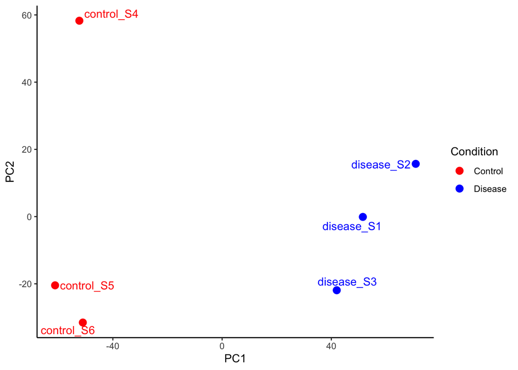

```r
# Plot using ggplot2

#Load the ggplot2 and ggrepel packages.

library(ggplot2)
library(ggrepel)

ggplot(pca_df, aes(x = PC1, y = PC2, color = Condition)) +
  #indicate that this is a dotplot
  geom_point(size = 3) +
  #create labels positioned to stay on the plot and not overlap
  geom_text_repel(aes(label = Name), show.legend = FALSE) +
  scale_color_manual(values = c("Control" = "red", "Disease" = "blue")) +
  labs(x = "PC1", y = "PC2") +
    theme_classic() + #creates plain white background
  theme(legend.position = "right")
```

```r
# check percent variation per PC
summary(pca)
```

```
Importance of components:
                           PC1     PC2     PC3     PC4      PC5       PC6
Standard deviation     60.8578 33.2680 27.6539 24.9791 22.09766 9.825e-14
Proportion of Variance  0.5538  0.1655  0.1143  0.0933  0.07302 0.000e+00
Cumulative Proportion   0.5538  0.7193  0.8337  0.9270  1.00000 1.000e+00
```

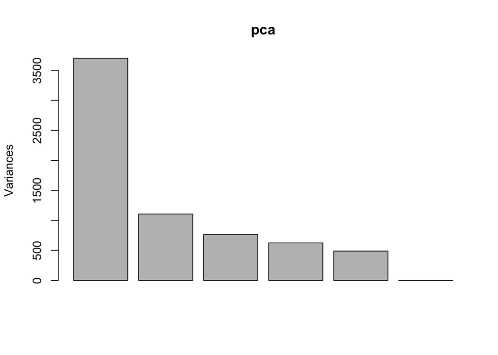

```r
screeplot(pca)
```

## 2.4 Heatmap

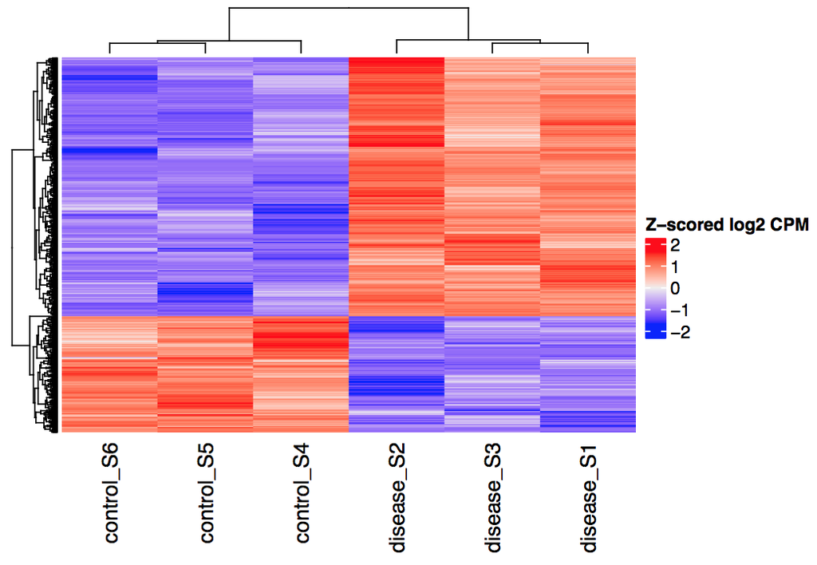

```r
library(ComplexHeatmap)
# Get a list of the differentially expressed genes, using a more stringent Q-value
degs.diff <- diff[diff$QValue < 0.01,]
# subset the log-scaled CPMs to get the same genes
degs.cpm <- norm.log[rownames(degs.diff),]
# we do want to z-score across the genes, to account for gene-to-gene
#    differences in baseline expression
# need to transpose twice, as the scale function works on columns
degs.cpm.z <- t(scale(t(degs.cpm)))
# heatmap, without gene names (too many) and label the color key
Heatmap(degs.cpm.z,show_row_names=F,name="Z-scored log2 CPM")
```

## 2.5 Volcano plot

- Use the annotated differential expression data. We will make a basic plot and a plot with coloring, labels, and dashed lines using ggplot2, and then label top 10 genes using ggrepel.

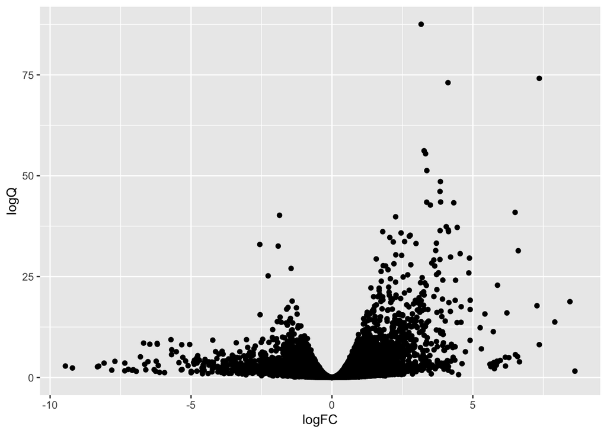

```r
diff <- read.table("diff_annotated.txt", header=T, row.names=1)

# May also read from public URL if file not saved previously

diff <- read.table("https://wd.cri.uic.edu/RNAseq/diff_annotated.txt", header=T, row.names=1)

# Add a category column for color mapping
diff$category <- "NS"
diff$category[diff$logFC > 0 & diff$QValue < 0.05] <- "Upregulated"
diff$category[diff$logFC < 0 & diff$QValue < 0.05] <- "Downregulated"


library(ggplot2)
library(ggrepel)

#Transform q values to put the most significant genes on top
diff$logQ = -log10(diff$QValue)

#Make a basic volcano plot
ggplot(diff, aes(x=logFC, y=logQ)) +
  geom_point()
```

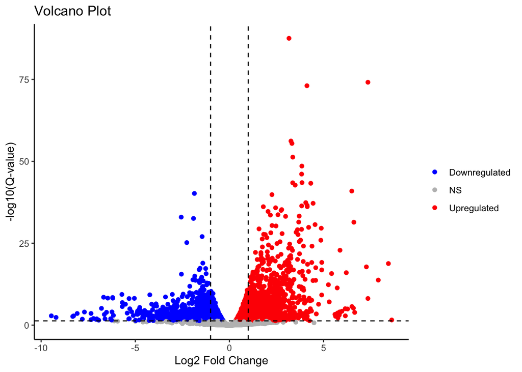

```r
# Add coloring, labels, and dashed lines (you can add to the previous plot commands to save time).
ggplot(diff, aes(x=logFC, y=logQ, color=category)) +
  geom_point() +
  #Vertical lines marking 2-fold up- and downregulation cutoffs
  geom_vline(xintercept = c(-1, 1), linetype = "dashed", color = "black") +
  #Horizontal line marking significance cutoff
  geom_hline(yintercept = -log10(0.05), linetype = "dashed", color = "black") +
  scale_color_manual(values = c("Upregulated" = "red", "Downregulated" = "blue", "NS" = "gray")) +
  #color="" removes the color legend title
  labs(x = "Log2 Fold Change", y = "-log10(Q-value)", title = "Volcano Plot", color = "") +
  theme_classic()
```

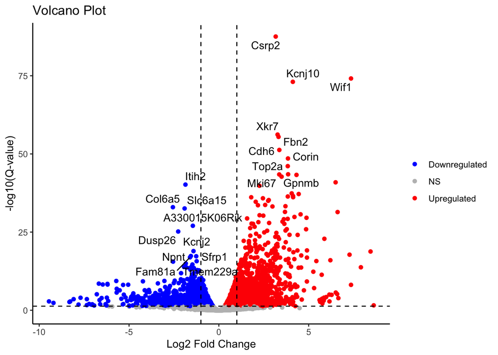

```r
#Label top 10 up- and downregulated genes using geom_text_repel()

# Select top 10 genes by smallest QValue
top_up <- diff[diff$category == "Upregulated", ]
top_up <- top_up[order(top_up$QValue), ][1:10, ]

top_down <- diff[diff$category == "Downregulated", ]
top_down <- top_down[order(top_down$QValue), ][1:10, ]

# Combine top genes for labeling
top_genes <- rbind(top_up, top_down)

ggplot(diff, aes(x=logFC, y=logQ, color=category)) +
  geom_point() +
  #Vertical lines marking 2-fold up- and downregulation cutoffs
  geom_vline(xintercept = c(-1, 1), linetype = "dashed", color = "black") +
  #Horizontal line marking significance cutoff
  geom_hline(yintercept = -log10(0.05), linetype = "dashed", color = "black") +
  scale_color_manual(values = c("Upregulated" = "red", "Downregulated" = "blue", "NS" = "gray")) +
  #color="" removes the color legend title
  labs(x = "Log2 Fold Change", y = "-log10(Q-value)", title = "Volcano Plot", color = "") +
  theme_classic() +
  geom_text_repel(data = top_genes, aes(label = gene_symbol), color = "black")
```

# 3 Take Home Exercises

## 3.1 Build STAR index

- Reference index setup:
  - Download whole-genome fasta file and GTF file of gene annotations

```bash
# This command should be in a single line
wget ftp://ftp.ensembl.org/pub/release-115/fasta/mus_musculus/dna/
Mus_musculus.GRCm39.dna.primary_assembly.fa.gz
#If not downloaded in the first exercise
wget ftp://ftp.ensembl.org/pub/release-115/gtf/mus_musculus/Mus_musculus.GRCm39.115.gtf.gz
gunzip Mus_musculus.GRCm39.dna.primary_assembly.fa.gz
gunzip Mus_musculus.GRCm39.115.gtf.gz
```

- Create script build_STAR_index.sh

```bash
cp ~/SLURM_template.sh build_STAR_index.sh
```

- Open the build_STAR_index.sh script for editing using nano

```bash
nano build_STAR_index.sh
```

- Edit the script to look like this (the STAR command should be in a single line):

```bash
#!/bin/sh
#SBATCH --mail-type=BEGIN,END,FAIL
#SBATCH --time=24:00:00
#SBATCH --mem=100G
#SBATCH --ntasks=4
#SBATCH --account=ric_workshop
#SBATCH --partition=batch
#SBATCH -o %x.o%J

cd $SLURM_SUBMIT_DIR


module load STAR
STAR --runMode genomeGenerate --genomeDir mm39_STAR
 --genomeFastaFiles Mus_musculus.GRCm39.dna.primary_assembly.fa
 --sjdbGTFfile Mus_musculus.GRCm39.115.gtf --sjdbOverhang 100
```

- Run SLURM script:

```bash
sbatch build_STAR_index.sh
```

## 3.2 Run featureCounts on STAR alignment results

- Use the BAM file resulting from Exercise 1.2.
- Create script run_feature_counts.sh

```bash
cp ~/SLURM_template.sh run_feature_counts.sh
```

- Open the run_feature_counts.sh script for editing using nano

```bash
nano run_feature_counts.sh
```

- Edit the script to look like this:

```bash
#!/bin/sh
#SBATCH --mail-type=BEGIN,END,FAIL
#SBATCH --time=100:00:00
#SBATCH --mem=100G
#SBATCH --ntasks=4
#SBATCH --account=ric_workshop
#SBATCH --partition=batch
#SBATCH -o %x.o%J

cd $SLURM_SUBMIT_DIR

module load Subread

featureCounts -T 8 -t exon -g gene_id -s 0 -p -a Mus_musculus.GRCm39.115.gtf
-o Control_S4_unsorted.counts Control_S4_STARAligned.out.bam
```

- Run SLURM script:

```bash
sbatch run_feature_counts.sh
```

- Look at the output file:

```bash
head Control_S4_unsorted.counts

# Program:featureCounts v2.0.4; Command:"featureCounts" "-T" "8" "-t" "exon" "-g" "gene_id" "-s" "0" "-p" "-a" "Mus_musculus.GRCm39.115.gtf" "-o" "Control_S4_unsorted.counts" "Control_S4_STARAligned.out.bam"
Geneid  Chr Start   End Strand  Length  Control_S4_STARAligned.out.bam
ENSMUSG00000104478  1   108344807   108347562   +   2756    0
ENSMUSG00000104385  1   6980784 6981446 +   663 0
ENSMUSG00000101231  1   108540067   108540244   -   178 0
ENSMUSG00000102135  1;1 6986783;6993624 6987219;6993812 +;+ 626 0
ENSMUSG00000103282  1   6999983 7000012 +   30  0
ENSMUSG00000101097  1   108697865   108699733   +   1869    0
ENSMUSG00000100764  1;1;1   43781121;43782744;43782986  43781266;43783012;43783055  -;-;-   458 9
ENSMUSG00000102534  1   7068441 7068765 +   325 0
```